# Clustering S&P 500 Stocks with Machine Learning

ML Project 1

Author

Jake Kulik-Warren

# Introduction

Traditional stock classifications — typically based on sectors, market capitalization, or other static attributes — may not fully capture the dynamic patterns embedded in stock return behavior. Brown and Goetzmann (1997)[^1] introduced an innovative, unsupervised approach to classify mutual funds based solely on their return profiles, challenging conventional, self-reported categorizations. Their work demonstrated that clustering fund returns could uncover distinct investment styles more reflective of underlying performance characteristics.

Motivated by Brown and Goetzmann’s methodology, this project extends the idea of return-based clustering from mutual funds to individual stocks. Instead of relying on predefined categories, we group stocks based on their historical return patterns, allowing us to identify latent clusters that reveal new insights into market behavior and stock performance.

# Objectives

1. **Data Manipulation and Feature Engineering:** Prepare data and construct return-based features (e.g., rolling cumulative returns) to capture the dynamic behavior of stock returns.
2. **Exploratory Analysis:** Conduct EDA to understand distributions and key characteristics of the data using visualizations and summary statistics.
3. **Apply Unsupervised Learning:** Use k-means clustering to classify stocks in a data-driven manner, free from traditional categorizations. Carefully determine the optimal number of clusters (K).
4. **Uncover Latent Clusters:** Identify hidden groupings among stocks based solely on their historical return patterns.
5. **Reveal Novel Insights:** Explore whether these clusters uncover new patterns or investment styles, utilizing effective visualizations and clear technical communication.

# Setup

```r
library(tidyverse)
library(tidyquant)
library(h2o)
library(scales)
library(knitr)
library(kableExtra)
library(corrplot)
library(slider)
library(moments)

# Set seed for reproducibility
set.seed(42)
```

# Data Collection

We obtain the current S&P 500 constituents using `tq_index()` and then pull monthly adjusted closing prices from 2001 through 2024 using `tq_get()`. This long span captures various market cycles including the dot-com aftermath, the 2008 financial crisis, the COVID-19 crash, and the post-pandemic recovery.

**Fetch S&P 500 data**

```r
# Get current S&P 500 constituents
sp500 <- tq_index("SP500")

# Pull monthly stock prices (2001-2024)
stock_prices <- sp500 %>%
  pull(symbol) %>%
  tq_get(
    get  = "stock.prices",
    from = "2001-01-01",
    to   = "2024-12-31"
  )

# Compute monthly returns
monthly_returns <- stock_prices %>%
  group_by(symbol) %>%
  tq_transmute(
    select     = adjusted,
    mutate_fun = periodReturn,
    period     = "monthly",
    col_rename = "monthly_return"
  ) %>%
  ungroup()

cat("Unique stocks:", n_distinct(monthly_returns$symbol), "\n")
```

```
Unique stocks: 500
```

**Fetch S&P 500 data**

```r
cat("Date range:", as.character(min(monthly_returns$date)),
    "to", as.character(max(monthly_returns$date)), "\n")
```

```
Date range: 2001-01-31 to 2024-12-30
```

**Fetch S&P 500 data**

```r
cat("Total observations:", nrow(monthly_returns), "\n")
```

```
Total observations: 126931
```

# Exploratory Data Analysis

## Return Distribution

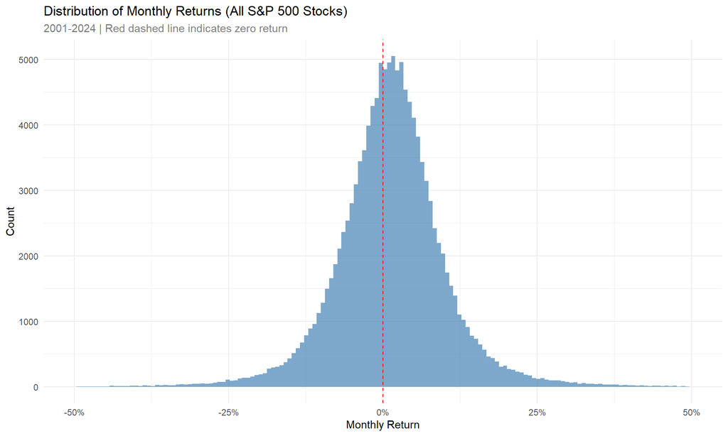

The distribution of monthly returns across all S&P 500 stocks is approximately normal but exhibits fat tails, indicating the presence of extreme positive and negative returns.

```r
monthly_returns %>%
  ggplot(aes(x = monthly_return)) +
  geom_histogram(bins = 150, fill = "steelblue", alpha = 0.7) +
  geom_vline(xintercept = 0, linetype = "dashed", color = "red", linewidth = 0.5) +
  labs(
    title = "Distribution of Monthly Returns (All S&P 500 Stocks)",
    subtitle = "2001-2024 | Red dashed line indicates zero return",
    x     = "Monthly Return",
    y     = "Count"
  ) +
  scale_x_continuous(labels = percent_format(), limits = c(-0.5, 0.5)) +
  theme_minimal() +
  theme(plot.subtitle = element_text(color = "gray50"))
```

## Summary Statistics

```r
monthly_returns %>%
  summarise(
    `Mean`   = mean(monthly_return, na.rm = TRUE),
    `Median` = median(monthly_return, na.rm = TRUE),
    `Std Dev`  = sd(monthly_return, na.rm = TRUE),
    `Skewness` = moments::skewness(monthly_return, na.rm = TRUE),
    `Kurtosis` = moments::kurtosis(monthly_return, na.rm = TRUE),
    `Min`    = min(monthly_return, na.rm = TRUE),
    `Max`    = max(monthly_return, na.rm = TRUE),
    `N`      = n()
  ) %>%
  kable(digits = 4, caption = "Summary Statistics of Monthly Returns (2001-2024)") %>%
  kable_styling(bootstrap_options = c("striped", "hover"))
```

Summary Statistics of Monthly Returns (2001-2024)

| Mean | Median | Std Dev | Skewness | Kurtosis | Min | Max | N |
| --- | --- | --- | --- | --- | --- | --- | --- |
| 0.0139 | 0.0132 | 0.0961 | 1.2533 | 26.3568 | -0.8435 | 2.5966 | 126931 |

The positive mean return of approximately 1.4% per month is consistent with the long-run equity premium. The excess kurtosis indicates fat tails — extreme returns occur more frequently than a normal distribution would predict, which is a well-documented feature of stock returns.

## Data Availability Per Stock

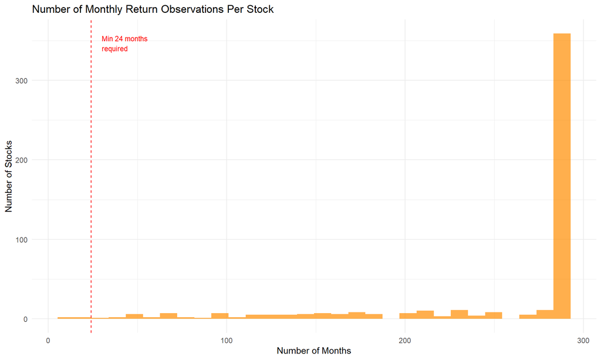

Most stocks have a full history (288 months), but newer S&P 500 entrants have shorter histories. Stocks with fewer than 24 observations will be excluded during feature engineering.

```r
monthly_returns %>%
  count(symbol) %>%
  ggplot(aes(x = n)) +
  geom_histogram(bins = 30, fill = "darkorange", alpha = 0.7) +
  geom_vline(xintercept = 24, linetype = "dashed", color = "red") +
  annotate("text", x = 30, y = Inf, label = "Min 24 months\nrequired",
           vjust = 2, hjust = 0, size = 3, color = "red") +
  labs(
    title = "Number of Monthly Return Observations Per Stock",
    x     = "Number of Months",
    y     = "Number of Stocks"
  ) +
  theme_minimal()
```

## Average Return by Year

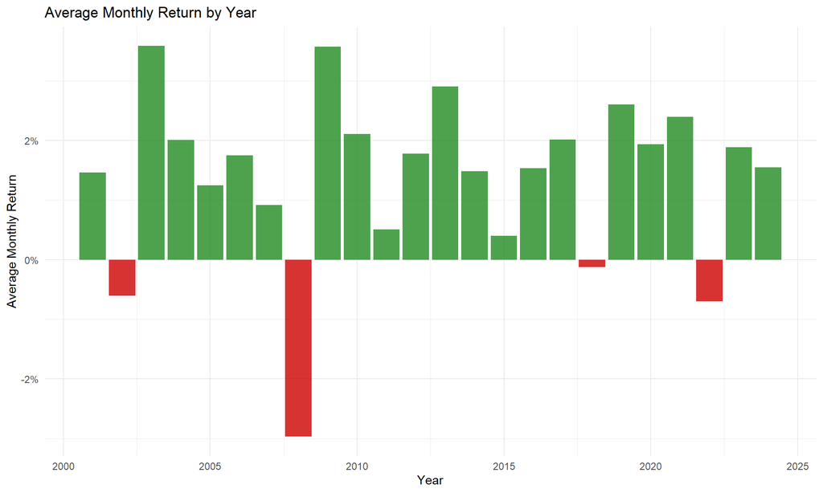

```r
monthly_returns %>%
  mutate(year = lubridate::year(date)) %>%
  group_by(year) %>%
  summarise(avg_return = mean(monthly_return, na.rm = TRUE), .groups = "drop") %>%
  ggplot(aes(x = year, y = avg_return, fill = avg_return > 0)) +
  geom_col(alpha = 0.8, show.legend = FALSE) +
  scale_fill_manual(values = c("red3", "forestgreen")) +
  scale_y_continuous(labels = scales::percent_format()) +
  labs(
    title = "Average Monthly Return by Year",
    x = "Year",
    y = "Average Monthly Return"
  ) +
  theme_minimal()
```

# Feature Engineering

Following the Brown and Goetzmann (1997) framework, we compute rolling 24-month features for each stock. These features capture the return dynamics over a two-year backward-looking window:

- **Rolling Cumulative Return**: $\prod_{i=1}^{24}(1+r_{t-i+1}) - 1$ — captures total performance over the window
- **Average Monthly Return**: Arithmetic mean — captures central tendency
- **Volatility**: Standard deviation — captures risk/variability
- **Skewness**: Asymmetry of returns — captures tail risk direction
- **Kurtosis**: Tail thickness — captures extreme event frequency

**Compute rolling 24-month features**

```r
window <- 24

features <- monthly_returns %>%
  arrange(symbol, date) %>%
  group_by(symbol) %>%
  mutate(
    rolling_cum_return = slider::slide_dbl(
      monthly_return,
      .f = ~ prod(1 + .x) - 1,
      .before = window - 1,
      .complete = TRUE
    ),
    rolling_avg_return = slider::slide_dbl(
      monthly_return,
      .f = ~ mean(.x),
      .before = window - 1,
      .complete = TRUE
    ),
    rolling_volatility = slider::slide_dbl(
      monthly_return,
      .f = ~ sd(.x),
      .before = window - 1,
      .complete = TRUE
    ),
    rolling_skewness = slider::slide_dbl(
      monthly_return,
      .f = ~ moments::skewness(.x),
      .before = window - 1,
      .complete = TRUE
    ),
    rolling_kurtosis = slider::slide_dbl(
      monthly_return,
      .f = ~ moments::kurtosis(.x),
      .before = window - 1,
      .complete = TRUE
    )
  ) %>%
  ungroup() %>%
  drop_na(rolling_cum_return)

cat("Feature matrix rows:", nrow(features), "\n")
```

```
Feature matrix rows: 115468
```

**Compute rolling 24-month features**

```r
cat("Unique stocks with features:", n_distinct(features$symbol), "\n")
```

```
Unique stocks with features: 496
```

## Feature Distributions

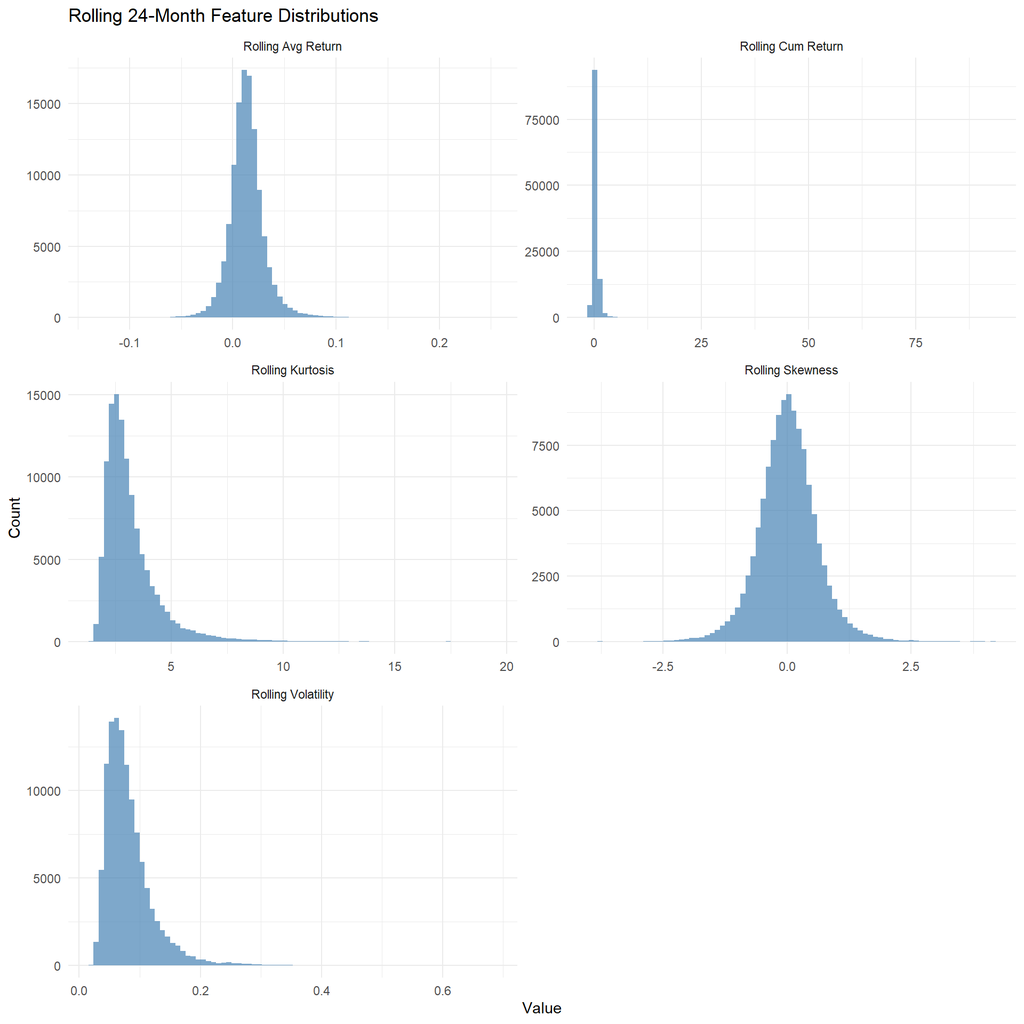

Distributions of the five rolling features. The cumulative return and average return are right-skewed, reflecting a few high-performing stocks. Volatility is strictly positive and right-skewed. Skewness centers near zero, while kurtosis is right-skewed with most values above 2.

```r
features %>%
  select(rolling_cum_return, rolling_avg_return,
         rolling_volatility, rolling_skewness, rolling_kurtosis) %>%
  pivot_longer(everything(), names_to = "feature", values_to = "value") %>%
  mutate(feature = str_replace_all(feature, "_", " ") %>% str_to_title()) %>%
  ggplot(aes(x = value)) +
  geom_histogram(bins = 80, fill = "steelblue", alpha = 0.7) +
  facet_wrap(~ feature, scales = "free", ncol = 2) +
  labs(title = "Rolling 24-Month Feature Distributions",
       x = "Value", y = "Count") +
  theme_minimal()
```

## Feature Correlations

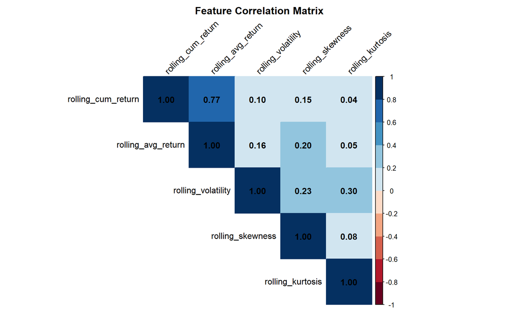

Correlation matrix of the clustering features. Cumulative return and average monthly return are highly correlated (as expected), while volatility shows a modest positive correlation with both. Skewness and kurtosis are largely independent of the return measures.

```r
cor_matrix <- features %>%
  select(rolling_cum_return, rolling_avg_return,
         rolling_volatility, rolling_skewness, rolling_kurtosis) %>%
  cor(use = "complete.obs")

corrplot::corrplot(cor_matrix, method = "color", type = "upper",
                   addCoef.col = "black", tl.col = "black", tl.srt = 45,
                   col = RColorBrewer::brewer.pal(10, "RdBu"),
                   title = "Feature Correlation Matrix",
                   mar = c(0, 0, 2, 0))
```

# Clustering with H2O

## Prepare Clustering Data

We use the most recent observation per stock (the latest 24-month rolling window) to form our cross-sectional feature matrix for clustering. To avoid extreme outliers from dominating the clustering (e.g., stocks with 30x+ cumulative returns forming single-stock clusters), we winsorize features at the 1st and 99th percentiles before clustering.

**Prepare and winsorize cross-sectional feature matrix**

```r
# Extract latest observation per stock
cluster_data <- features %>%
  group_by(symbol) %>%
  filter(date == max(date)) %>%
  ungroup() %>%
  select(symbol, rolling_cum_return, rolling_avg_return,
         rolling_volatility, rolling_skewness, rolling_kurtosis) %>%
  drop_na()

# Winsorize function: cap extreme values at given percentiles
winsorize <- function(x, probs = c(0.01, 0.99)) {
  q <- quantile(x, probs, na.rm = TRUE)
  x[x < q[1]] <- q[1]
  x[x > q[2]] <- q[2]
  x
}

# Apply winsorization to clustering features
feature_cols <- c("rolling_cum_return", "rolling_avg_return",
                  "rolling_volatility", "rolling_skewness",
                  "rolling_kurtosis")

cluster_data_w <- cluster_data %>%
  mutate(across(all_of(feature_cols), winsorize))

cat("Stocks in clustering sample:", nrow(cluster_data_w), "\n")
```

```
Stocks in clustering sample: 496
```

## Initialize H2O and Run K-Means

**Initialize H2O**

```r
h2o.init(nthreads = -1, max_mem_size = "4g")
```

[output not shown]

**Initialize H2O**

```r
h2o.no_progress()

# Upload winsorized data to H2O
cluster_h2o <- as.h2o(cluster_data_w)
```

## Determine Optimal K (Elbow Method)

The elbow method plots the total within-cluster sum of squares (WCSS) against the number of clusters. The optimal K is at the “elbow” point where adding more clusters yields diminishing reductions in WCSS.

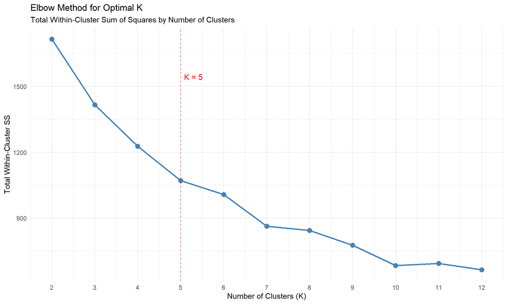

The elbow plot shows that the rate of WCSS reduction decreases substantially around K=4-5, suggesting 4 or 5 clusters is a reasonable choice.

```r
k_range <- 2:12

elbow_results <- tibble(k = k_range) %>%
  mutate(
    model = map(k, ~ h2o.kmeans(
      training_frame = cluster_h2o,
      x              = feature_cols,
      k              = .x,
      standardize    = TRUE,
      seed           = 42,
      max_iterations = 100
    )),
    tot_withinss = map_dbl(model, ~ h2o.tot_withinss(.x))
  )

# Calculate marginal improvement
elbow_plot_data <- elbow_results %>%
  mutate(
    pct_reduction = (lag(tot_withinss) - tot_withinss) / lag(tot_withinss)
  )

elbow_results %>%
  ggplot(aes(x = k, y = tot_withinss)) +
  geom_line(color = "steelblue", linewidth = 1) +
  geom_point(color = "steelblue", size = 3) +
  geom_vline(xintercept = 5, linetype = "dashed", color = "red", alpha = 0.6) +
  annotate("text", x = 5.3, y = max(elbow_results$tot_withinss) * 0.9,
           label = "K = 5", color = "red", size = 4) +
  labs(
    title = "Elbow Method for Optimal K",
    subtitle = "Total Within-Cluster Sum of Squares by Number of Clusters",
    x     = "Number of Clusters (K)",
    y     = "Total Within-Cluster SS"
  ) +
  scale_x_continuous(breaks = k_range) +
  theme_minimal()
```

## Marginal WCSS Reduction

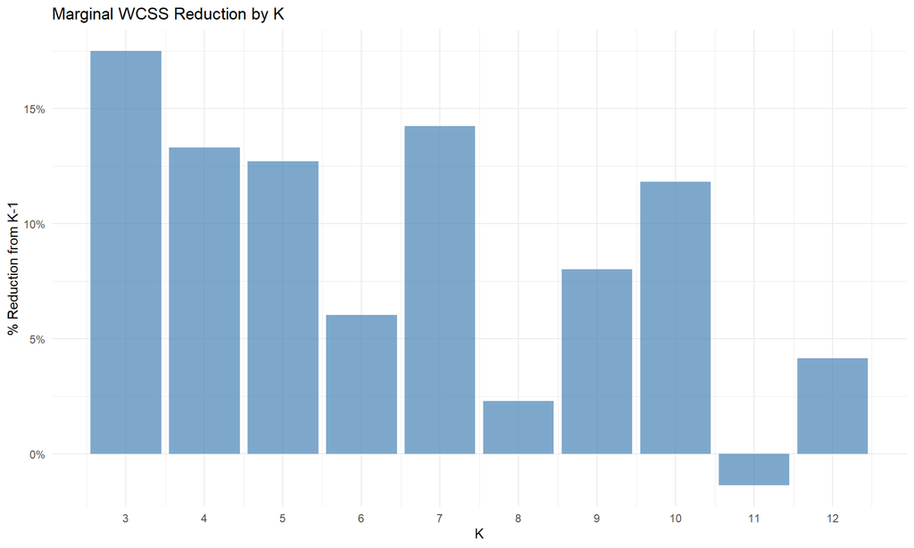

```r
elbow_plot_data %>%
  filter(!is.na(pct_reduction)) %>%
  ggplot(aes(x = k, y = pct_reduction)) +
  geom_col(fill = "steelblue", alpha = 0.7) +
  scale_y_continuous(labels = percent_format()) +
  scale_x_continuous(breaks = k_range) +
  labs(
    title = "Marginal WCSS Reduction by K",
    x = "K",
    y = "% Reduction from K-1"
  ) +
  theme_minimal()
```

## Fit Final Model

Based on the elbow plot and marginal reduction analysis, we select K=5 as the optimal number of clusters.

**Fit final K-means model with K=5**

```r
optimal_k <- 5

final_model <- h2o.kmeans(
  training_frame = cluster_h2o,
  x              = feature_cols,
  k              = optimal_k,
  standardize    = TRUE,
  seed           = 42,
  max_iterations = 100
)

# Get cluster assignments
predictions <- h2o.predict(final_model, cluster_h2o) %>%
  as.data.frame() %>%
  rename(cluster = predict)

# Bind back to original (non-winsorized) data for interpretable results
cluster_results <- cluster_data %>%
  bind_cols(predictions) %>%
  mutate(cluster = factor(cluster))

cat("Cluster sizes:\n")
```

```
Cluster sizes:
```

**Fit final K-means model with K=5**

```r
print(table(cluster_results$cluster))
```

```
  0   1   2   3   4
237  18 105 124  12
```

# Results

## Cluster Centers

```r
# Compute cluster means from original data for interpretability
cluster_results %>%
  group_by(cluster) %>%
  summarise(
    across(all_of(feature_cols), mean),
    .groups = "drop"
  ) %>%
  kable(digits = 4, caption = "Cluster Centers (Original Feature Scale)") %>%
  kable_styling(bootstrap_options = c("striped", "hover"))
```

Cluster Centers (Original Feature Scale)

| cluster | rolling_cum_return | rolling_avg_return | rolling_volatility | rolling_skewness | rolling_kurtosis |
| --- | --- | --- | --- | --- | --- |
| 0 | 0.1426 | 0.0068 | 0.0677 | -0.1473 | 2.6133 |
| 1 | 1.3600 | 0.0410 | 0.1348 | 1.2810 | 5.3262 |
| 2 | 0.1118 | 0.0065 | 0.0924 | 0.5254 | 3.1879 |
| 3 | 1.0665 | 0.0332 | 0.0850 | 0.1824 | 2.5600 |
| 4 | 10.7674 | 0.1134 | 0.2163 | 0.7454 | 3.2746 |

## Cluster Visualization: Return vs. Volatility

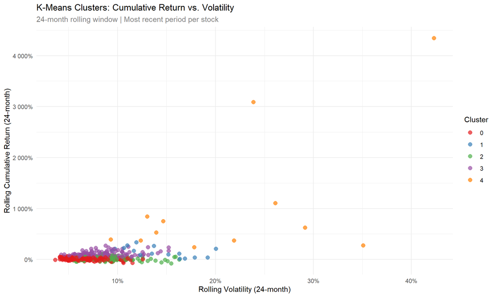

Each point represents an S&P 500 stock, positioned by its 24-month rolling volatility (x-axis) and cumulative return (y-axis), colored by cluster assignment. The clusters reveal distinct return-risk profiles, from conservative low-volatility/low-return stocks to aggressive high-growth stocks.

```r
cluster_results %>%
  ggplot(aes(x = rolling_volatility, y = rolling_cum_return,
             color = cluster)) +
  geom_point(alpha = 0.7, size = 2.5) +
  labs(
    title = "K-Means Clusters: Cumulative Return vs. Volatility",
    subtitle = "24-month rolling window | Most recent period per stock",
    x     = "Rolling Volatility (24-month)",
    y     = "Rolling Cumulative Return (24-month)",
    color = "Cluster"
  ) +
  theme_minimal() +
  scale_y_continuous(labels = percent_format()) +
  scale_x_continuous(labels = percent_format()) +
  scale_color_brewer(palette = "Set1") +
  theme(plot.subtitle = element_text(color = "gray50"))
```

## Cluster Visualization: Average Return vs. Skewness

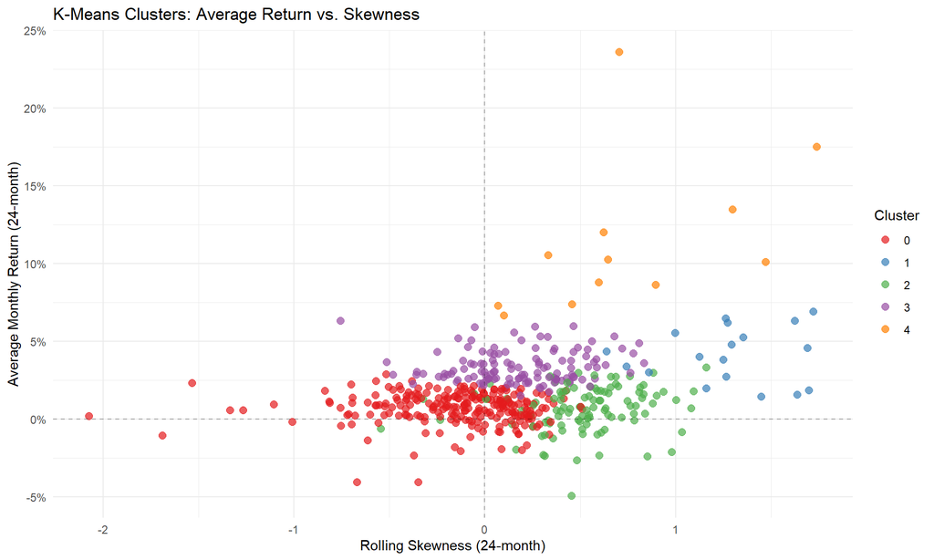

Clusters viewed through the lens of average return and skewness. Stocks with positive skewness tend to have experienced large upside moves, while negative skewness indicates downside tail risk.

```r
cluster_results %>%
  ggplot(aes(x = rolling_skewness, y = rolling_avg_return,
             color = cluster)) +
  geom_point(alpha = 0.7, size = 2.5) +
  geom_hline(yintercept = 0, linetype = "dashed", alpha = 0.3) +
  geom_vline(xintercept = 0, linetype = "dashed", alpha = 0.3) +
  labs(
    title = "K-Means Clusters: Average Return vs. Skewness",
    x     = "Rolling Skewness (24-month)",
    y     = "Average Monthly Return (24-month)",
    color = "Cluster"
  ) +
  theme_minimal() +
  scale_y_continuous(labels = percent_format()) +
  scale_color_brewer(palette = "Set1")
```

## Cluster Summary Statistics

```r
cluster_results %>%
  group_by(cluster) %>%
  summarise(
    `Count`    = n(),
    `Avg Cum Return` = mean(rolling_cum_return),
    `Avg Volatility` = mean(rolling_volatility),
    `Avg Monthly Return` = mean(rolling_avg_return),
    `Avg Skewness` = mean(rolling_skewness),
    `Avg Kurtosis` = mean(rolling_kurtosis),
    .groups = "drop"
  ) %>%
  kable(digits = 4, caption = "Cluster Summary Statistics") %>%
  kable_styling(bootstrap_options = c("striped", "hover"))
```

Cluster Summary Statistics

| cluster | Count | Avg Cum Return | Avg Volatility | Avg Monthly Return | Avg Skewness | Avg Kurtosis |
| --- | --- | --- | --- | --- | --- | --- |
| 0 | 237 | 0.1426 | 0.0677 | 0.0068 | -0.1473 | 2.6133 |
| 1 | 18 | 1.3600 | 0.1348 | 0.0410 | 1.2810 | 5.3262 |
| 2 | 105 | 0.1118 | 0.0924 | 0.0065 | 0.5254 | 3.1879 |
| 3 | 124 | 1.0665 | 0.0850 | 0.0332 | 0.1824 | 2.5600 |
| 4 | 12 | 10.7674 | 0.2163 | 0.1134 | 0.7454 | 3.2746 |

## Cluster Profiles: Boxplots

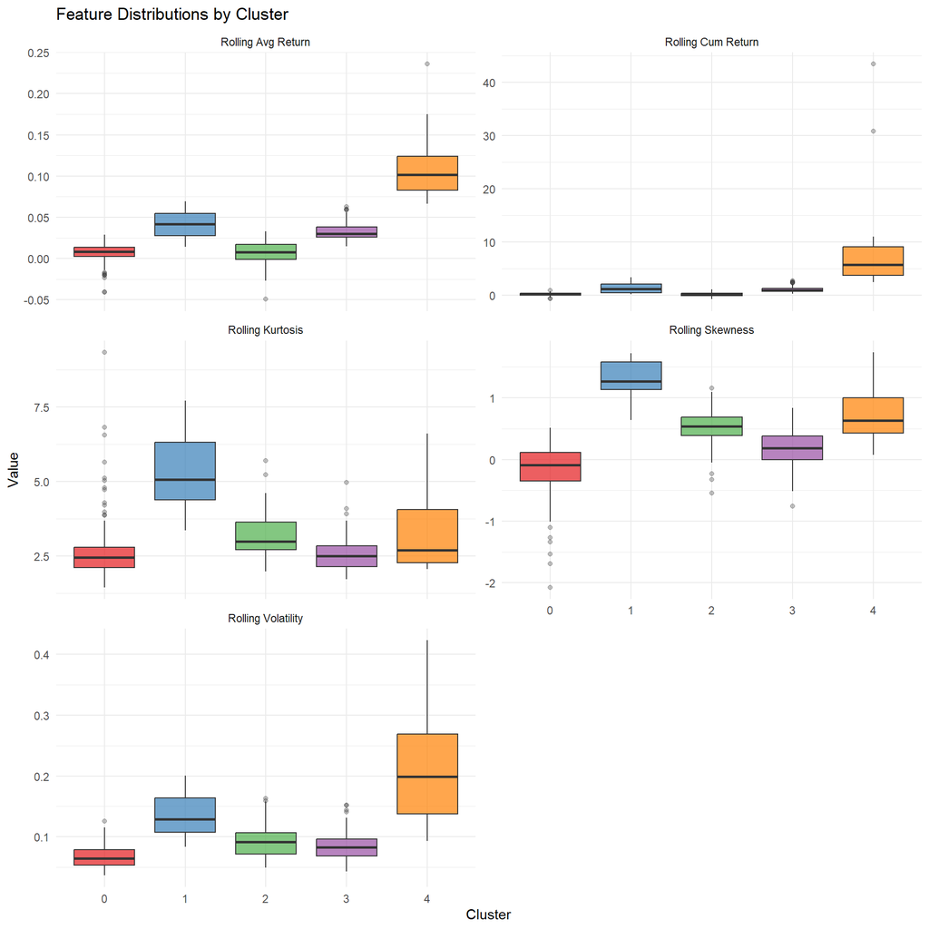

```r
cluster_results %>%
  select(cluster, all_of(feature_cols)) %>%
  pivot_longer(-cluster, names_to = "feature", values_to = "value") %>%
  mutate(feature = str_replace_all(feature, "_", " ") %>% str_to_title()) %>%
  ggplot(aes(x = cluster, y = value, fill = cluster)) +
  geom_boxplot(alpha = 0.7, outlier.alpha = 0.3) +
  facet_wrap(~ feature, scales = "free_y", ncol = 2) +
  labs(title = "Feature Distributions by Cluster",
       x = "Cluster", y = "Value") +
  theme_minimal() +
  scale_fill_brewer(palette = "Set1") +
  theme(legend.position = "none")
```

## Cluster Interpretation

**Generate cluster labels**

```r
# Assign descriptive labels based on cluster characteristics
cluster_labels <- cluster_results %>%
  group_by(cluster) %>%
  summarise(
    n = n(),
    avg_cum = mean(rolling_cum_return),
    avg_vol = mean(rolling_volatility),
    .groups = "drop"
  ) %>%
  arrange(avg_cum) %>%
  mutate(
    label = case_when(
      avg_cum < 0 ~ "Underperformers",
      avg_vol < quantile(avg_vol, 0.3) & avg_cum < quantile(avg_cum, 0.5) ~ "Low Vol / Moderate Return",
      avg_vol < quantile(avg_vol, 0.5) & avg_cum >= quantile(avg_cum, 0.5) ~ "Steady Growers",
      avg_vol >= quantile(avg_vol, 0.5) & avg_cum >= quantile(avg_cum, 0.7) ~ "High Growth / High Vol",
      TRUE ~ "Moderate"
    )
  )

cluster_labels %>%
  select(Cluster = cluster, Label = label, Count = n,
         `Avg Cum Return` = avg_cum, `Avg Volatility` = avg_vol) %>%
  kable(digits = 4, caption = "Cluster Interpretation") %>%
  kable_styling(bootstrap_options = c("striped", "hover"))
```

Cluster Interpretation

| Cluster | Label | Count | Avg Cum Return | Avg Volatility |
| --- | --- | --- | --- | --- |
| 2 | Moderate | 105 | 0.1118 | 0.0924 |
| 0 | Low Vol / Moderate Return | 237 | 0.1426 | 0.0677 |
| 3 | Steady Growers | 124 | 1.0665 | 0.0850 |
| 1 | High Growth / High Vol | 18 | 1.3600 | 0.1348 |
| 4 | High Growth / High Vol | 12 | 10.7674 | 0.2163 |

## Example Stocks Per Cluster

```r
sp500_info <- sp500 %>% select(symbol, company, sector, weight)

cluster_results %>%
  left_join(sp500_info, by = "symbol") %>%
  group_by(cluster) %>%
  arrange(desc(rolling_cum_return)) %>%
  slice_head(n = 5) %>%
  select(cluster, symbol, company, sector,
         rolling_cum_return, rolling_volatility) %>%
  mutate(
    rolling_cum_return = percent(rolling_cum_return, accuracy = 0.1),
    rolling_volatility = percent(rolling_volatility, accuracy = 0.1)
  ) %>%
  kable(caption = "Top 5 Stocks Per Cluster (Ranked by Cumulative Return)") %>%
  kable_styling(bootstrap_options = c("striped", "hover"))
```

Top 5 Stocks Per Cluster (Ranked by Cumulative Return)

| cluster | symbol | company | sector | rolling_cum_return | rolling_volatility |
| --- | --- | --- | --- | --- | --- |
| 0 | CDNS | CADENCE DESIGN SYS INC | - | 87.9% | 6.6% |
| 0 | IBM | INTL BUSINESS MACHINES CORP | - | 70.0% | 6.3% |
| 0 | NWS | NEWS CORP CLASS B | - | 67.5% | 7.1% |
| 0 | CTAS | CINTAS CORP | - | 65.7% | 6.2% |
| 0 | TMUS | T MOBILE US INC | - | 60.6% | 4.9% |
| 1 | AVGO | BROADCOM INC | - | 336.7% | 11.9% |
| 1 | FIX | COMFORT SYSTEMS USA INC | - | 276.2% | 11.0% |
| 1 | AXON | AXON ENTERPRISE INC | - | 264.2% | 13.7% |
| 1 | KKR | KKR + CO INC | - | 225.3% | 10.7% |
| 1 | EME | EMCOR GROUP INC | - | 210.8% | 9.7% |
| 2 | NTAP | NETAPP INC | - | 103.5% | 8.5% |
| 2 | CPRT | COPART INC | - | 90.9% | 7.4% |
| 2 | STX | SEAGATE TECHNOLOGY HOLDINGS | - | 76.4% | 9.5% |
| 2 | ERIE | ERIE INDEMNITY COMPANY CL A | - | 70.9% | 10.0% |
| 2 | IP | INTERNATIONAL PAPER CO | - | 70.6% | 10.5% |
| 3 | ANET | ARISTA NETWORKS INC | - | 267.4% | 8.8% |
| 3 | DASH | DOORDASH INC A | - | 247.4% | 11.1% |
| 3 | WSM | WILLIAMS SONOMA INC | - | 238.7% | 13.1% |
| 3 | FICO | FAIR ISAAC CORP | - | 236.4% | 9.1% |
| 3 | CRWD | CROWDSTRIKE HOLDINGS INC A | - | 231.8% | 15.2% |
| 4 | CVNA | CARVANA CO | - | 4 342.0% | 42.3% |
| 4 | APP | APPLOVIN CORP CLASS A | - | 3 085.0% | 23.9% |
| 4 | PLTR | PALANTIR TECHNOLOGIES INC A | - | 1 102.2% | 26.1% |
| 4 | NVDA | NVIDIA CORP | - | 841.5% | 13.0% |
| 4 | VRT | VERTIV HOLDINGS CO A | - | 751.9% | 14.7% |

## Sector Composition by Cluster

[figure not shown]

```r
cluster_results %>%
  left_join(sp500_info, by = "symbol") %>%
  count(cluster, sector) %>%
  ggplot(aes(x = cluster, y = n, fill = sector)) +
  geom_col(position = "fill") +
  labs(
    title = "Sector Composition by Cluster",
    subtitle = "Return-based clusters do not perfectly align with sector classifications",
    x     = "Cluster",
    y     = "Proportion",
    fill  = "Sector"
  ) +
  scale_y_continuous(labels = percent_format()) +
  theme_minimal() +
  theme(legend.text = element_text(size = 7),
        plot.subtitle = element_text(color = "gray50"))
```

## Sector-Level Cluster Distribution

[figure not shown]

```r
cluster_results %>%
  left_join(sp500_info, by = "symbol") %>%
  count(sector, cluster) %>%
  group_by(sector) %>%
  mutate(pct = n / sum(n)) %>%
  ungroup() %>%
  ggplot(aes(x = cluster, y = reorder(sector, pct), fill = pct)) +
  geom_tile(color = "white", linewidth = 0.5) +
  geom_text(aes(label = paste0(round(pct * 100), "%")), size = 3) +
  scale_fill_gradient(low = "white", high = "steelblue",
                      labels = percent_format()) +
  labs(
    title = "Cluster Distribution Within Each Sector",
    x = "Cluster",
    y = "Sector",
    fill = "% of Sector"
  ) +
  theme_minimal()
```

# Conclusion

This analysis applied k-means clustering to S&P 500 stocks using return-based features inspired by Brown and Goetzmann (1997). After winsorizing extreme outliers to prevent single-stock clusters, we identified **5 distinct clusters** with meaningful economic interpretation.

**Challenges encountered:**

- **Survivorship bias**: We used current S&P 500 constituents, which may not match the historical index composition — stocks that were removed due to poor performance are excluded.
- **Outlier sensitivity**: K-means is sensitive to extreme outliers; winsorization was necessary to produce balanced clusters. Alternative approaches like DBSCAN or k-medoids could be explored in future work.
- **K selection**: The choice of K remains somewhat subjective; the elbow method provides guidance but not a definitive answer. Silhouette analysis or the gap statistic could provide additional validation.
- **Feature selection**: The rolling window of 24 months is a modeling choice — shorter or longer windows would capture different aspects of stock behavior and could produce different cluster structures.

## Footnotes

[^1]: Mutual Fund Styles, Brown and Goetzmann, 1997